# Homework 10

Solutions for Questions 1 and 2 will be available after Monday, November 2, 2026. No solution will be provided for Question 3.

Use the RLT package for Questions 1 and 2: `RLT` in R or `rlt` in Python. The node-size parameter is `nmin` in R and `min_samples_leaf` in Python; both stop splitting a node when it contains at most that many observations. The candidate-predictor parameter is `mtry` in both languages. Use ordinary random forests, with reinforcement turned off.

## Question 1: Bias-variance trade-off simulation

Two important tuning parameters of random forests are node size and `mtry`. We have performed some preliminary analysis in class. The goal of this question is to perform a larger simulation study for these two tuning parameters.

Consider a regression model with five jointly normally distributed predictors. Each predictor has mean 0 and variance 1, and the correlation between any two different predictors is 0.3. The response is

$$Y=X_1+X_3+X_5+\varepsilon,
\qquad \varepsilon\sim N(0,1),$$

where the noise is independent of the predictors. Thus the true regression function is $f(\mathbf{x})=x_1+x_3+x_5$.

1. Set up a simulation study with 100 repetitions. Generate 200 test predictor vectors once and keep them fixed. In each repetition, generate 200 new training observations and use the same training data for all tuning settings. Fit 500-tree forests, drawing 200 observations with replacement for each tree. Make the following two comparisons:
   - Fix `mtry` at 3 and vary node size over $1,5,10,20,30$.
   - Fix node size at 10 and vary `mtry` over $1,2,3,4,5$.

   Leave all other fitting parameters at their defaults. Record the predictions at each test point across repetitions. For each setting, estimate the squared bias and variance at each test point, then average them over the 200 test points. Compare predictions with $f(\mathbf{x})$ when estimating bias. Produce two figures, one for each tuning parameter, showing the averaged squared bias and variance. Set a random seed and report it.
2. Discuss your results in terms of the bias-variance trade-off:
   - How does a large node size, such as 30, affect the fit in this example?
   - What are the benefits and drawbacks of using a large `mtry` value?
   - If each tree instead sampled 100 observations with replacement, would you expect the preferred node size to shift toward smaller or larger values? Explain your reasoning. You may use an additional simulation to help, but a particular pattern is not guaranteed.

## Solution to Question 1

### (a)

I use seed 43210. The 200 test predictor vectors are generated once and reused in all 100 repetitions. In each repetition, I generate an independent training data set of 200 observations. The training data are not sampled from the test data; both data sets come from the same population. Within a repetition, all tuning settings use the same training data.

```r
library(RLT)
library(ggplot2)
set.seed(43210)

n_test <- 200
n_train <- 200
n_repetitions <- 100
n_trees <- 500

sigma <- matrix(0.3, nrow = 5, ncol = 5)
diag(sigma) <- 1

test_x <- MASS::mvrnorm(n_test, mu = rep(0, 5), Sigma = sigma)
colnames(test_x) <- paste0("X", 1:5)
true_test <- test_x[, 1] + test_x[, 3] + test_x[, 5]

node_sizes <- c(1, 5, 10, 20, 30)
mtry_values <- 1:5

node_predictions <- array(
  NA_real_,
  dim = c(n_test, n_repetitions, length(node_sizes))
)
mtry_predictions <- array(
  NA_real_,
  dim = c(n_test, n_repetitions, length(mtry_values))
)

for (b in seq_len(n_repetitions)) {
  train_x <- MASS::mvrnorm(n_train, mu = rep(0, 5), Sigma = sigma)
  colnames(train_x) <- paste0("X", 1:5)
  train_y <- train_x[, 1] + train_x[, 3] + train_x[, 5] +
    rnorm(n_train)

  for (j in seq_along(node_sizes)) {
    fit <- RLT(
      x = train_x, y = train_y, ntrees = n_trees,
      nmin = node_sizes[j], mtry = 3, resample.prob = 1,
      reinforcement = FALSE
    )
    node_predictions[, b, j] <- predict(fit, test_x)$Prediction
  }

  for (j in seq_along(mtry_values)) {
    fit <- RLT(
      x = train_x, y = train_y, ntrees = n_trees,
      nmin = 10, mtry = mtry_values[j], resample.prob = 1,
      reinforcement = FALSE
    )
    mtry_predictions[, b, j] <- predict(fit, test_x)$Prediction
  }
}
```

For each test point, the squared bias is the squared difference between the mean prediction and the true regression function. The variance is the variance of the 100 predictions. I then average each quantity over the 200 test points.

```r
summarize_predictions <- function(predictions, tuning_values, parameter) {
  results <- data.frame(
    tuning_value = tuning_values,
    squared_bias = NA_real_,
    variance = NA_real_
  )

  for (j in seq_along(tuning_values)) {
    prediction_matrix <- predictions[, , j]
    mean_prediction <- rowMeans(prediction_matrix)
    results$squared_bias[j] <- mean((mean_prediction - true_test)^2)
    results$variance[j] <- mean(apply(prediction_matrix, 1, var))
  }

  results$parameter <- parameter
  results
}

node_results <- summarize_predictions(
  node_predictions, node_sizes, "Node size"
)
mtry_results <- summarize_predictions(
  mtry_predictions, mtry_values, "mtry"
)

node_results
```

```
  tuning_value squared_bias   variance parameter
1            1    0.2928211 0.11182475 Node size
2            5    0.2936002 0.09921917 Node size
3           10    0.3224414 0.08195057 Node size
4           20    0.4188158 0.06549951 Node size
5           30    0.5309173 0.05739285 Node size
```

```r
mtry_results
```

```
  tuning_value squared_bias   variance parameter
1            1    0.8799247 0.04361774      mtry
2            2    0.4353420 0.06361373      mtry
3            3    0.3226611 0.08180617      mtry
4            4    0.2758740 0.09841100      mtry
5            5    0.2512246 0.11178047      mtry
```

The following figures compare the averaged squared bias and variance for the two tuning parameters.

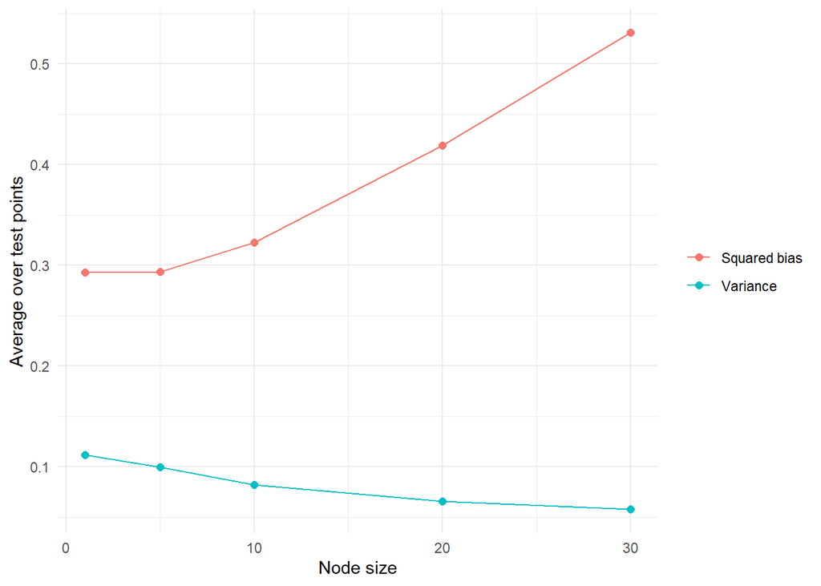

```r
plot_results <- function(results, x_label) {
  long_results <- rbind(
    data.frame(
      tuning_value = results$tuning_value,
      measure = "Squared bias",
      value = results$squared_bias
    ),
    data.frame(
      tuning_value = results$tuning_value,
      measure = "Variance",
      value = results$variance
    )
  )

  ggplot(long_results, aes(tuning_value, value, color = measure)) +
    geom_line() +
    geom_point(size = 2) +
    labs(x = x_label, y = "Average over test points", color = NULL) +
    theme_minimal()
}

plot_results(node_results, "Node size")
```

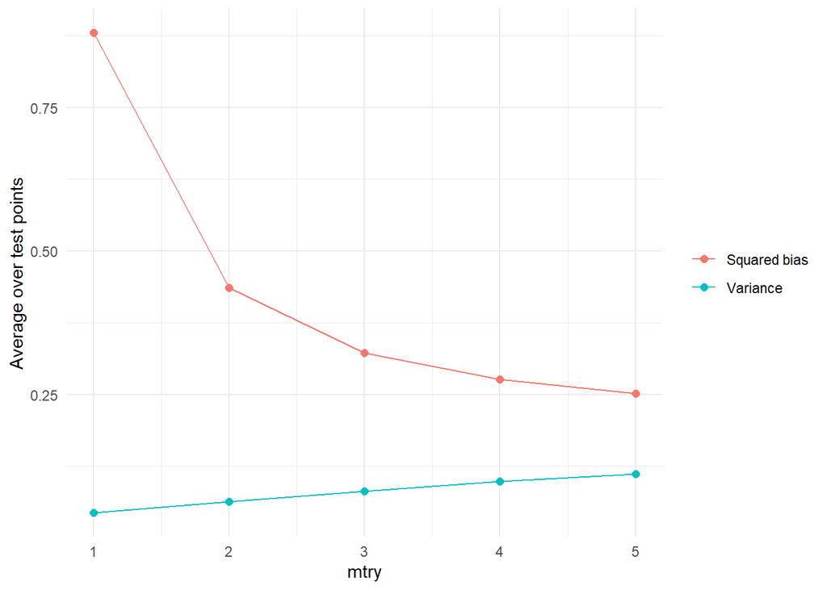

```r
plot_results(mtry_results, "mtry")
```

### (b)

The numerical results show the expected trade-off for node size. As node size increases from 1 to 30, the squared bias increases from about 0.293 to 0.531, while the variance decreases from about 0.112 to 0.057. A larger node size stops splitting earlier, so the trees are less flexible and less sensitive to the particular training sample. In this example, node size 30 therefore gives a more stable but more biased, underfit forest.

The results for `mtry` show the opposite pattern. As `mtry` increases from 1 to 5, squared bias decreases from about 0.880 to 0.251, while variance increases from about 0.044 to 0.112. A larger `mtry` makes important predictors available more often, which improves the individual trees and reduces bias. However, the trees become more similar because they use more similar candidate predictors. Their predictions are therefore more correlated, so averaging gives less variance reduction. A smaller `mtry` creates more diverse trees, but an important predictor may be unavailable at a split, increasing bias.

If each tree sampled only 100 observations with replacement, I would expect smaller node sizes to become more reasonable. Each tree would receive less information, so using a very large node size could make the trees especially underfit. This is a qualitative expectation rather than a guaranteed pattern; the simulation results would determine how strong the change is in this example.

## Question 2: Tuning random forests for MNIST

Use `mnist-first2000.csv.gz` from the combined ZIP. It contains 2,000 MNIST observations, with the digit label `Digit` and 784 pixel values.

- From the first 1,000 observations, keep digits 1, 6, and 7 as the training data. From the remaining 1,000 observations, keep the same digits as the test data.
- Fit PCA to the training pixels, centering but not scaling them. Use the first 20 principal components as predictors, and project the test observations using the same training means and loadings.

Complete the following tasks using RLT classification forests with 1,000 trees. For each tree, draw a bootstrap sample of the same size as the training set.

1. Fit a random forest with the default `mtry` and node-size settings. Report the out-of-bag (OOB) misclassification rate.
2. Construct a grid of `mtry` and node-size values to tune the model. Select the setting using OOB misclassification rate. Report the OOB error for each setting and the selected values. Calculate and present the selected forest’s OOB permutation variable importance for the 20 principal components. Comment on your results.
3. Apply the selected model to the test data and report the misclassification rate and confusion matrix. Use the test labels only for this final assessment.

## Solution to Question 2

### (a)

I use the first 1,000 observations to form the training data and the remaining observations to form the test data. I retain only digits 1, 6, and 7. PCA is fit using the training pixels only, so the test observations do not affect the centering or the principal-component directions.

```r
library(RLT)
library(ggplot2)

set.seed(43211)

mnist <- read.csv(gzfile("data/mnist-first2000.csv.gz"))
train_raw <- mnist[1:1000, ]
test_raw <- mnist[1001:2000, ]
keep_digits <- c(1, 6, 7)
train_raw <- train_raw[train_raw$Digit %in% keep_digits, ]
test_raw <- test_raw[test_raw$Digit %in% keep_digits, ]

pixel_names <- setdiff(names(mnist), "Digit")
train_pixels <- as.matrix(train_raw[, pixel_names])
test_pixels <- as.matrix(test_raw[, pixel_names])

pca <- prcomp(train_pixels, center = TRUE, scale. = FALSE)
train_pc <- pca$x[, 1:20]
test_centered <- sweep(
  test_pixels, 2, pca$center, FUN = "-"
)
test_pc <- test_centered %*% pca$rotation[, 1:20]
colnames(train_pc) <- paste0("PC", 1:20)
colnames(test_pc) <- paste0("PC", 1:20)

train_y <- factor(train_raw$Digit, levels = keep_digits)
test_y <- factor(test_raw$Digit, levels = keep_digits)

default_fit <- RLT(
  x = train_pc, y = train_y, model = "classification",
  ntrees = 1000, resample.prob = 1, reinforcement = FALSE
)
default_oob <- tail(default_fit$AllError[, "nonPermute"], 1)
default_oob
```

```
 Tree1000
0.1525424
```

The `nonPermute` column gives the cumulative OOB misclassification rate. The default forest uses the package’s default `mtry` and node-size values, while `resample.prob = 1` makes each tree draw a bootstrap sample the same size as the training data.

### (b)

I use a 20-setting grid. The grid includes five `mtry` values and four node-size values, while all forests use the same number of trees and bootstrap sampling scheme.

```r
mtry_grid <- c(2, 5, 10, 15, 20)
nmin_grid <- c(1, 5, 10, 20)
tuning_grid <- expand.grid(
  mtry = mtry_grid,
  nmin = nmin_grid
)
tuning_grid$oob_error <- NA_real_
tuned_fits <- vector("list", nrow(tuning_grid))

for (i in seq_len(nrow(tuning_grid))) {
  fit <- RLT(
    x = train_pc, y = train_y, model = "classification",
    ntrees = 1000, mtry = tuning_grid$mtry[i],
    nmin = tuning_grid$nmin[i], resample.prob = 1,
    reinforcement = FALSE
  )
  tuning_grid$oob_error[i] <- tail(
    fit$AllError[, "nonPermute"], 1
  )
  tuned_fits[[i]] <- fit
}

tuning_grid[order(tuning_grid$oob_error), ]
```

```
   mtry nmin  oob_error
19   15   20 0.05084746
4    15    1 0.06779661
14   15   10 0.06923077
15   20   10 0.08620690
3    10    1 0.10077519
20   20   20 0.10317460
12    5   10 0.10434783
5    20    1 0.10619469
10   20    5 0.10743802
8    10    5 0.13793103
2     5    1 0.14285714
18   10   20 0.15789474
7     5    5 0.16528926
13   10   10 0.16806723
9    15    5 0.18032787
17    5   20 0.19512195
6     2    5 0.19819820
1     2    1 0.28571429
16    2   20 0.32258065
11    2   10 0.37704918
```

```r
best_index <- which.min(tuning_grid$oob_error)
best_setting <- tuning_grid[best_index, ]
selected_fit <- tuned_fits[[best_index]]
best_setting
```

```
   mtry nmin  oob_error
19   15   20 0.05084746
```

The selected forest is the setting with the smallest OOB misclassification rate. Its OOB permutation importance is reported for all 20 principal components.

```r
importance_results <- data.frame(
  component = paste0("PC", 1:20),
  importance = as.numeric(selected_fit$VarImp[1, 1:20])
)
importance_results <- importance_results[
  order(importance_results$importance, decreasing = TRUE),
]
importance_results
```

```
   component  importance
2        PC2 3.766362564
1        PC1 1.924263063
3        PC3 0.226798449
11      PC11 0.134890373
5        PC5 0.129951963
6        PC6 0.098820607
18      PC18 0.055839968
4        PC4 0.049380235
7        PC7 0.034481653
16      PC16 0.029114689
14      PC14 0.028908024
12      PC12 0.025446778
10      PC10 0.022863150
8        PC8 0.020706609
19      PC19 0.020040280
17      PC17 0.018113755
13      PC13 0.017673157
20      PC20 0.014780230
9        PC9 0.011848700
15      PC15 0.009981206
```

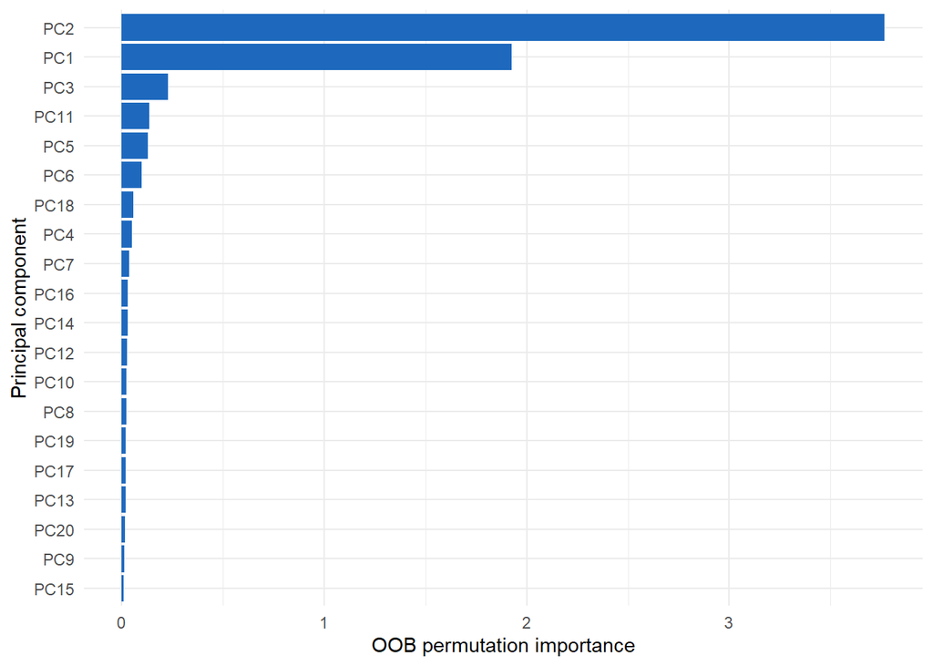

```r
ggplot(
  importance_results,
  aes(x = reorder(component, importance), y = importance)
) +
  geom_col(fill = "#1E69BE") +
  coord_flip() +
  labs(
    x = "Principal component",
    y = "OOB permutation importance"
  ) +
  theme_minimal()
```

The OOB error table compares the tuning settings without using the test labels. Principal components with larger permutation importance contribute more to prediction accuracy in this forest. This is predictive importance, not evidence that a principal component or its original pixel variables cause the digit label.

### (c)

I use the test labels only for this final assessment.

```r
test_prediction_index <- predict(selected_fit, test_pc)$Prediction
test_prediction <- factor(
  selected_fit$ylevels[test_prediction_index + 1],
  levels = keep_digits
)
test_confusion <- table(
  Actual = test_y,
  Predicted = test_prediction
)
test_error <- mean(test_prediction != test_y)

test_error
```

```
[1] 0.02208202
```

```r
test_confusion
```

```
      Predicted
Actual   1   6   7
     1 103   0   1
     6   2 103   1
     7   0   3 104
```

The test misclassification rate and confusion matrix measure how well the selected forest generalizes to the held-out observations.

## Question 3: Planning a random-forest analysis skill

In earlier homework, some students wrote long skill files with detailed instructions, while others wrote short skills emphasizing their specific requirements or references. These approaches may perform differently depending on the AI and the task. A capable AI may already know standard ways to perform an analysis, so some instructions may be redundant, add little value, or sometimes make the analysis worse. It may be more useful to specify your personal choices for the analysis. An AI with more limited knowledge may benefit from detailed instructions that remind it of the steps to perform.

1. Write one paragraph describing how you would write a skill that directs an AI to perform a random-forest analysis and produce a report for a future dataset. Discuss how you would balance standard analysis instructions with your personal preferences, considering the AI’s capabilities.
2. Provide **10 instructions** you would consider including in the skill, **ordered from the most basic instructions to the more personal preferences**. Your list may cover computation, tuning, tables, figures, interpretation, presentation, or other aspects of a random-forest report.

You only need to discuss how the skill should be written. You are not required to write a complete skill file or test it.

## Solution to Question 3

### (a)

I would write the skill so that it gives the AI the standard steps for a random-forest analysis, but does not repeat procedures that the AI already knows well. For example, the skill could say that the AI should inspect the data, tune the model, evaluate its performance, and explain the results. However, it should give more specific instructions for the parts where my preferences matter, such as the structure of the report, the types of plots, the color palette, and how to communicate decisions. The skill should also require the AI to point out discrepancies or assumptions instead of silently making choices. If the AI already knows a reliable procedure, it can skip detailed reminders about that procedure, but it should still report what it did so that the analysis is reproducible and understandable.

### (b)

1. Import the data and inspect its structure, including the variable types, sample size, and whether there are missing values.
2. Compare the data with the user’s description. Identify the response column or columns and the predictor variables, and tell the user about any discrepancies.
3. Check whether the response and predictors are suitable for the requested random-forest analysis, including checking the response classes and possible data-entry problems.
4. Evaluate the data size and use it to choose a reasonable grid of node sizes and `mtry` values. Explain any choices that are not obvious.
5. Fit the random forests for every setting in the grid, using the same evaluation procedure for all settings, and report the results.
6. Use out-of-bag error, or cross-validation when appropriate, to select the best model. Report the full tuning results and the selected values rather than reporting only the final model.
7. Calculate variable importance and include an appropriate interpretation. Clearly distinguish predictive importance from evidence that a predictor causes changes in the response.
8. Create a two-page short summary report, including the assumptions, methods, decisions made during the analysis, results, limitations, and conclusion. Do not hide important choices in the code.
9. Use color-blind-friendly colors with enough contrast, avoid very light colors, and choose plot types that directly match the quantities being displayed.
10. When possible, use the UIUC color palette and keep the tables, figures, and writing visually consistent throughout the report.